# IMPACT R user training

21st-22nd May 2019

## IMPACT 2.0. Strategy:

- Standardising products and processes  
- Being everywhere  
- Mainstreaming technological tools

## IMPACT 2.0. Strategy: Data Unit edition

- Standardising products and processes  
- Being everywhere  
- Mainstreaming technological tools

**using R and other software to do this**

[figure not shown]

## For this to happen

- **Capacity**  
- Processes  
- Sustainable Change

# Data Unit capacity building framework

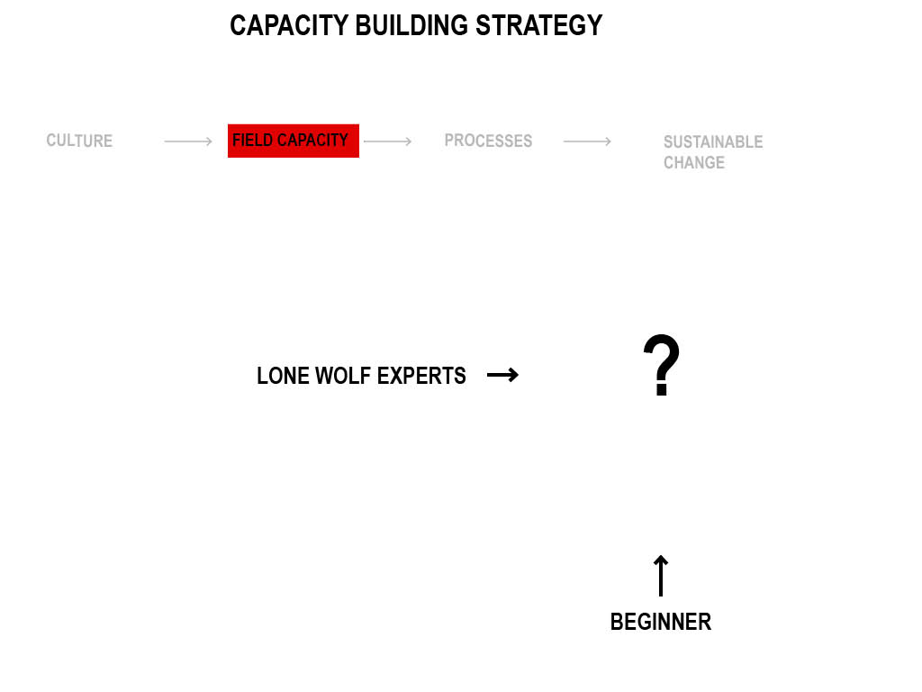

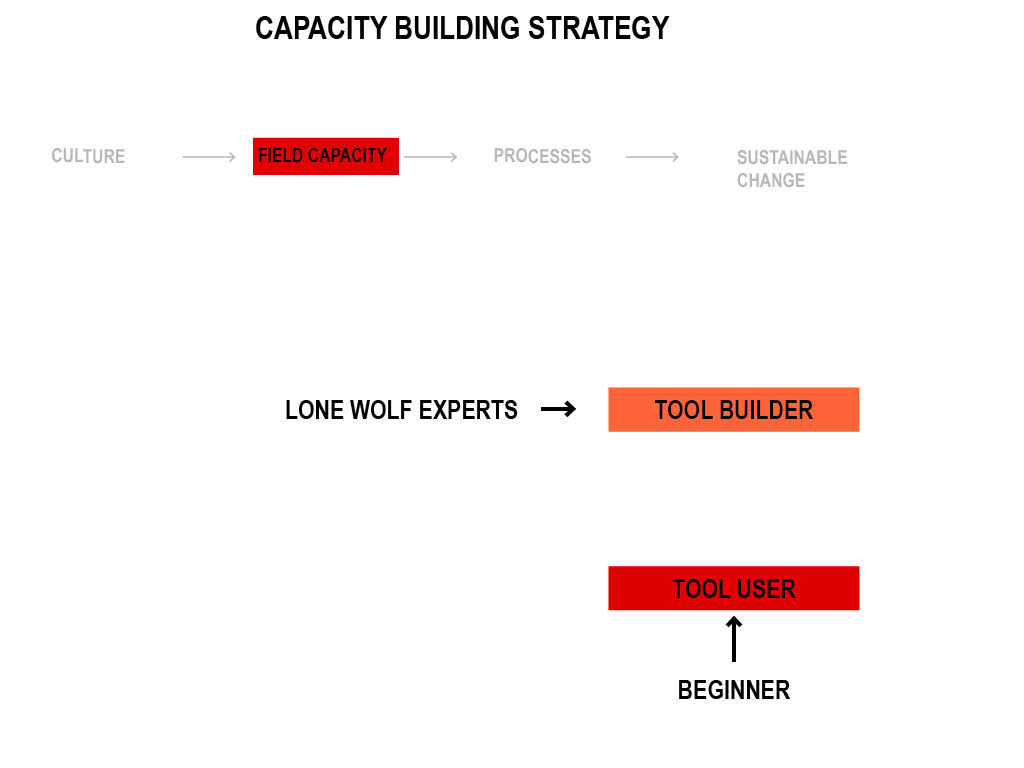

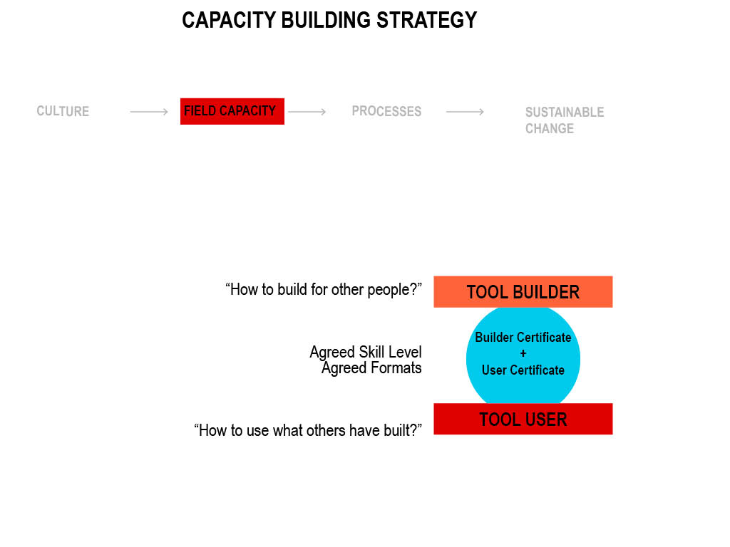

## After last training

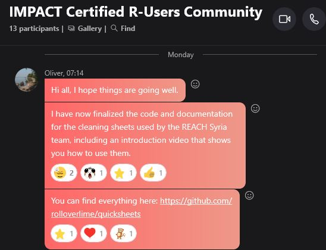

## After last training

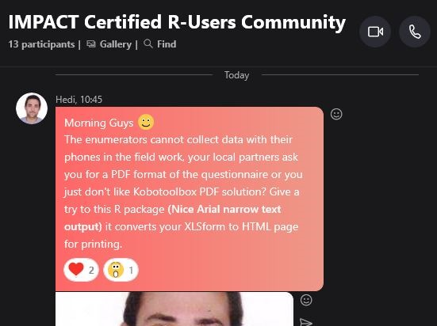

# Dynamic capacity building framework

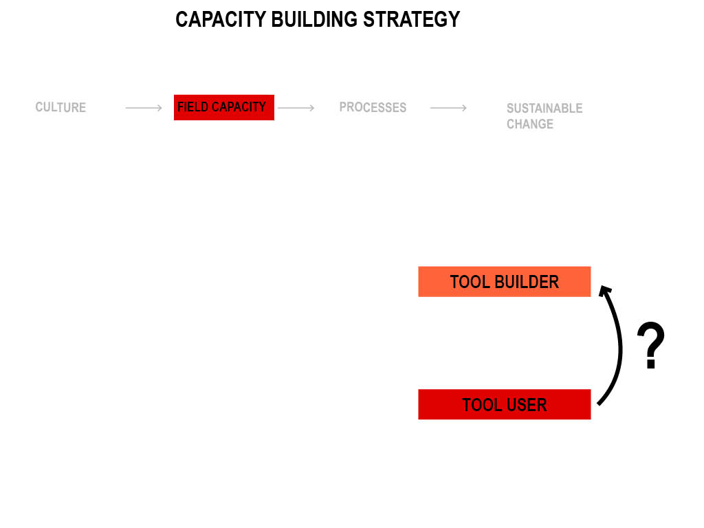

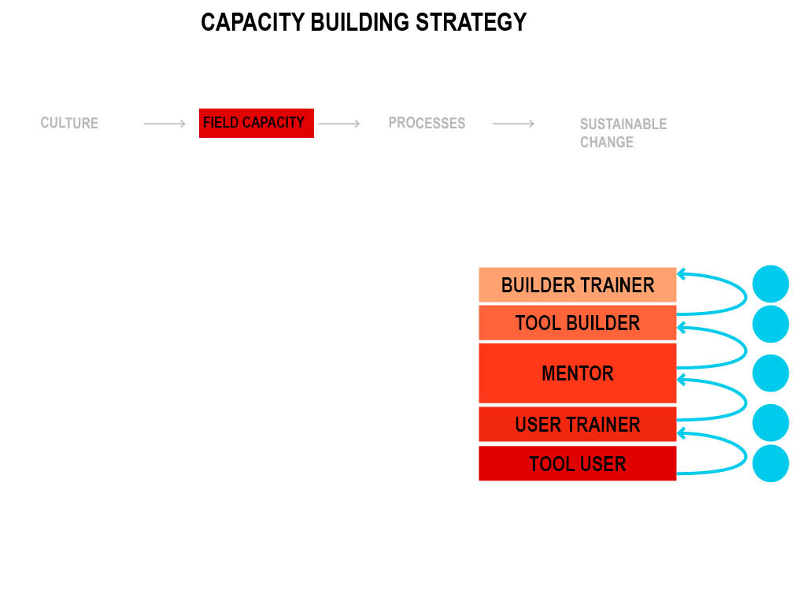

# Learning Goals

## NOT the learning Goals

- *Not* a training on specific tools  
- *Not* a data science degree in 2.5 days  
- (not statistics)  
- (not generic R)  
- (not quantitative research methods)

## Learning Goals

*“Not a training on specific tools”*

*Instead*: how to access and use all current and future (R) tools developed in IMPACT  
(with specific tools as concrete examples)

*“Not a data science degree in 2.5 days”*

*Instead*: the first step on your way to becoming a data scientist  
Focused on collaboration, reproducibility, documentation…

## Agenda

**Day1**  
* Intro to R and overview of packages  
**Day2**  
* Example Project workflow  
- with practical exercises for each step  
**Day3**  
* Hypothesis tests  
* Certification tests  
**Day 4**  
* Brainstorm and Hackathon

## After this training you will

- Know how to **download, load, and use** the core packages at IMPACT
- (hopefully) be able to transfer that knowledge to your teams
- Be a part of the IMPACT certified R user community  
  *R sepcific:
- Load packages
- Load and save data from R
- Access and use documentation
- Functions
- Basic debugging
- Collaborate on GitHub

# Introduction and motivations

## Questions!

- Questions are everything!
- Might feel hard because there are so MANY easy things at once.
- You are here because you are really talented

## This is a second Pilot

- Things will go wrong
- I need your feedback
- No one in the humanitarian system has (successfully) done this before

## Agenda

*day 1*  
- 17:00 - 19:00 Introduction / Overview of R packages

*day 2*  
- 09:00 - 10:30 Sharing R tools at IMPACT *cleaninginspectoR*  
- 11:00 - 13:00 Debugging *koboloops*  
- 14:00 - 14:30 **Working together**  
- 14:30 - 16:30 R environments *koboquest*  
- 17:00 - 19:00 Documentation *surveyweights*

*day 3*  
- 09:00 - 10:30 Hypothesis tests : why we do them  
- 11:00 - 12:30 Hypothesis tests *HypegrammaR*  
- 12:30 - 13:00 **Certification Test: Work on solutions**

*day 4*  
- 09:00 - 10:30 Bonus session: Brainstorm

## Mechanics

- The “I dont know how to” board
- Cheatsheets
- Questions: always, no hand raising
- No phones please :)

## Feedback / questions ?

# 1.1.3 why R is Powerful

## *a primitive function*: R commands

```r
sum(1,1)
```

```
## [1] 2
```

```r
sum
```

```
## function (..., na.rm = FALSE)  .Primitive("sum")
```

## *a function*: A few lines of code turned into a new command

```r
colSums(some_data[,c(1:2)])
```

```
##    some_variable another_variable
##        -18.94249        151.96988
```

The code behind:

```r
colSums
```

```
## function (x, na.rm = FALSE, dims = 1L)
## {
##     if (is.data.frame(x))
##         x <- as.matrix(x)
##     if (!is.array(x) || length(dn <- dim(x)) < 2L)
##         stop("'x' must be an array of at least two dimensions")
##     if (dims < 1L || dims > length(dn) - 1L)
##         stop("invalid 'dims'")
##     n <- prod(dn[id <- seq_len(dims)])
##     dn <- dn[-id]
##     z <- if (is.complex(x))
##         .Internal(colSums(Re(x), n, prod(dn), na.rm)) + (0+1i) *
##             .Internal(colSums(Im(x), n, prod(dn), na.rm))
##     else .Internal(colSums(x, n, prod(dn), na.rm))
##     if (length(dn) > 1L) {
##         dim(z) <- dn
##         dimnames(z) <- dimnames(x)[-id]
##     }
##     else names(z) <- dimnames(x)[[dims + 1L]]
##     z
## }
## <bytecode: 0x0000000019da3520>
## <environment: namespace:base>
```

**THIS CHANGES EVERYTHING!!! WHY?**

## a “complicated” function

```r
library(keras)
application_resnet50
```

```
## function (include_top = TRUE, weights = "imagenet", input_tensor = NULL,
##     input_shape = NULL, pooling = NULL, classes = 1000)
## {
##     verify_application_prerequistes()
##     keras$applications$ResNet50(include_top = include_top, weights = weights,
##         input_tensor = input_tensor, input_shape = as_nullable_integer(input_shape),
##         pooling = pooling, classes = as.integer(classes))
## }
## <bytecode: 0x000000001912ef88>
## <environment: namespace:keras>
```

## *Exercise* write a function

A function that takes a numer, adds two and prints the result

## *Exercise* write a function

A function that takes a numer, adds two and prints the result

Things to consider: - Arguments - Naming your function - Returning something

## A package

a collection of functions that solve a specific problem

- Standardised
- Reliable
- Documented
- locked & hidden details
- “Stackable”: can be used in other functions/packages
- Shared through a standardised channel

## the Result

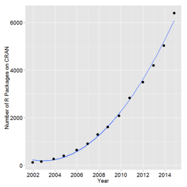

[source](https://www.r-bloggers.com/on-the-growth-of-cran-packages/)

## Questions/Feedback?

# Accessing R Packages

## Finding Packages

- google *“how to …. in R”*
- tutorials
- https://rseek.org/
- https://awesome-r.com/
- https://support.rstudio.com/hc/en-us/articles/201057987-Quick-list-of-useful-R-packages
- the classics: tidyverse, sf, lubridate, survey, magrittr, rmarkdown
- RStudio conference (youtube)
- Twitter

## Install

```r
install.packages("UpSetR")
```

## Load

```r
library("UpSetR")
```

## Learn

```r
?UpSetR
?upset
```

## Use

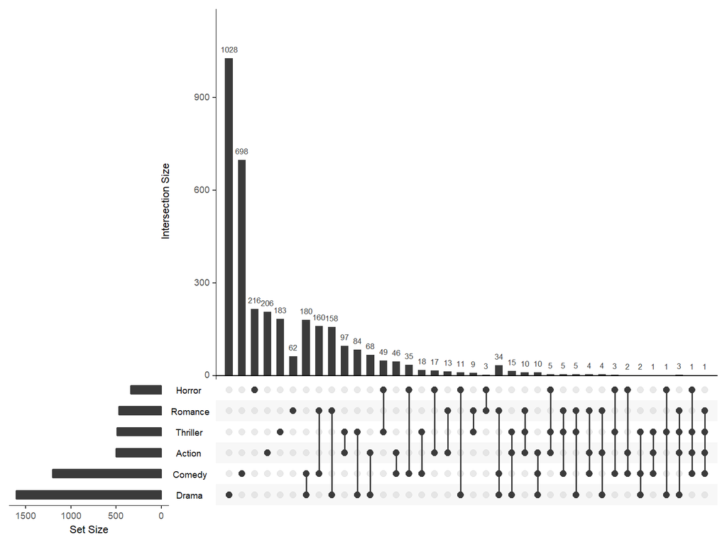

```r
upset(movies, nsets = 6)
```

## Behind the curtains

```r
upset
```

```
## function (data, nsets = 5, nintersects = 40, sets = NULL, keep.order = F,
##     set.metadata = NULL, intersections = NULL, matrix.color = "gray23",
##     main.bar.color = "gray23", mainbar.y.label = "Intersection Size",
##     mainbar.y.max = NULL, sets.bar.color = "gray23", sets.x.label = "Set Size",
##     point.size = 2.2, line.size = 0.7, mb.ratio = c(0.7, 0.3),
##     expression = NULL, att.pos = NULL, att.color = main.bar.color,
##     order.by = c("freq", "degree"), decreasing = c(T, F), show.numbers = "yes",
##     number.angles = 0, group.by = "degree", cutoff = NULL, queries = NULL,
##     query.legend = "none", shade.color = "gray88", shade.alpha = 0.25,
##     matrix.dot.alpha = 0.5, empty.intersections = NULL, color.pal = 1,
##     boxplot.summary = NULL, attribute.plots = NULL, scale.intersections = "identity",
##     scale.sets = "identity", text.scale = 1, set_size.angles = 0)
## {
##     startend <- FindStartEnd(data)
##     first.col <- startend[1]
##     last.col <- startend[2]
##     if (color.pal == 1) {
##         palette <- c("#1F77B4", "#FF7F0E", "#2CA02C", "#D62728",
##             "#9467BD", "#8C564B", "#E377C2", "#7F7F7F", "#BCBD22",
##             "#17BECF")
##     }
##     else {
##         palette <- c("#E69F00", "#56B4E9", "#009E73", "#F0E442",
##             "#0072B2", "#D55E00", "#CC79A7")
##     }
##     if (is.null(intersections) == F) {
##         Set_names <- unique((unlist(intersections)))
##         Sets_to_remove <- Remove(data, first.col, last.col, Set_names)
##         New_data <- Wanted(data, Sets_to_remove)
##         Num_of_set <- Number_of_sets(Set_names)
##         if (keep.order == F) {
##             Set_names <- order_sets(New_data, Set_names)
##         }
##         All_Freqs <- specific_intersections(data, first.col,
##             last.col, intersections, order.by, group.by, decreasing,
##             cutoff, main.bar.color, Set_names)
##     }
##     else if (is.null(intersections) == T) {
##         Set_names <- sets
##         if (is.null(Set_names) == T || length(Set_names) == 0) {
```

[output cut: 111 more lines]

```
##         show.numbers, mb.ratio, customQBar, number.angles, EBar_data,
##         mainbar.y.label, mainbar.y.max, scale.intersections,
##         text.scale, attribute.plots))
##     Matrix <- Make_matrix_plot(Matrix_layout, Set_sizes, All_Freqs,
##         point.size, line.size, text.scale, labels, ShadingData,
##         shade.alpha)
##     Sizes <- Make_size_plot(Set_sizes, sets.bar.color, mb.ratio,
##         sets.x.label, scale.sets, text.scale, set_size.angles)
##     Make_base_plot(Main_bar, Matrix, Sizes, labels, mb.ratio,
##         att.x, att.y, New_data, expression, att.pos, first.col,
##         att.color, AllQueryData, attribute.plots, legend, query.legend,
##         BoxPlots, Set_names, set.metadata, set.metadata.plots)
## }
## <bytecode: 0x000000001e7e9e20>
## <environment: namespace:UpSetR>
```

full source code: google *“PACKAGENAME site:www.github.com”*

## Exercise - Brainstorm

What kind of issues could be solved with a package ?

# day 2

## Agenda

- 09:00 - 10:30 R tools at IMPACT **cleaninginspectoR**
- 11:00 - 13:00 Debugging **koboquest**
- 14:00 - 14:30 Sharing tools: **Hedi’s magic**
- 14:30 - 15:00 Adding to the list of requested tools
- 15:30 - 16:30 *koboloops*
- 17:00 - 19:00 R environments **surveyweights**

## Day 1 recap & feedback

# R Packages on Github

## Project workflow

Check data cleaning  
Import questionnaire and choices from kobo Merge loops Calculate weights  
Calculate results

## Gitwhat?

## *git*

### a system to manage code projects

- track and save changes (rewind!)
- manage parallel versions
- merge versions
- collaborate

## *Github*

### an online platform for git

- collaborate online
- share code
- interact with users/developers
  - bug reports
  - feature requests
  - *not*: asking for help (stackoverflow!)

example 1: [This Presentation](https://github.com/ellieallien/impact_R_user_training/)

example 2: [the 2019 MSNA tool](https://github.com/mabafaba/msna18/network)

example 3: [issues (ggplot2)](https://github.com/tidyverse/ggplot2/issues)

## Installing R packages from Github

```r
devtools::install_github("ellieallien/cleaninginspectoR",
                        build_opts = c()
                        )
```

- “USERNAME/REPOSITORYNAME”
- `build_opts=c()`: makes sure to also download the manual (see `?remotes::install_github`)

## Load

```r
library("cleaninginspectoR")
```

### Learn

Overview:

```r
?cleaninginspectoR
```

Manuals / Help Documents

```r
browseVignettes("cleaninginspectoR")
```

List all functions

```r
ls("package:cleaninginspectoR")
```

Type `Packagename::` and hit `tab` to see available functions

| contents |
| --- |
| find_duplicates |
| find_duplicates_uuid |
| find_other_responses |
| find_outliers |
| inspect_all |
| sensitive_columns |

Use!

## Solution:

```r
data <- read.csv("./exercise_material/data_clean.csv", stringsAsFactors = F)
library(tidyr)
data %>% inspect_all(., "X_uuid") %>% write.csv(., "issues.csv")
```

## Bonus

- Create a function for an additional test (enumerator IDs, time spent, …)

# day 2

## Agenda

- 09:20 - 10:00 Day 1 review and feedback
- 10:00 - 12:30 Debugging **koboquest**
- 14:00 - 14:30 Sharing tools: **Hedi’s magic**
- 14:30 - 15:00 Adding to the list of requested tools
- 15:30 - 16:30 *koboloops*
- 17:00 - 19:00 R environments **surveyweights**

# Day 1 evening recap

## Creating functions

```r
### Define function
add_two <- function(x = 7){
y <- x+2
return(y)
}

### Call function
add_two(x = 10)
```

```
## [1] 12
```

## Working with packages

### Install

```r
devtools::install_github("ellieallien/cleaninginspectoR",
                        build_opts = c()
                        )
```

### Load

```r
library("cleaninginspectoR")
```

### Learn

Overview:

```r
?cleaninginspectoR
```

Manuals / Help Documents

```r
browseVignettes("cleaninginspectoR")
```

## List all functions

```r
ls("package:cleaninginspectoR")
```

```
## [1] "find_duplicates"      "find_duplicates_uuid" "find_other_responses"
## [4] "find_outliers"        "inspect_all"          "sensitive_columns"
```

## Practical exercise

## Load

```r
data <- read.csv("./exercise_material/data_raw.csv", stringsAsFactors = F)
```

What’s STRINGS AS FACTORS = FALSE?

## Loading objects general overview::

If you load something into your console it disappears after that line of code  
If you load something into a names object, it stays in your R sessions  
If you load something back onto your computer (for example with write.csv, then it stays on your computer)

Remember ?

```r
add_two(x = 10)
x
```

Versus

```r
x <- add_two(x = 10)
x
```

## Project plan

Check data cleaning **Import questionnaire and choices** to identify select multiple questions  
**Merge loops** to calculate water supply for each HH  
**Calculate weights** on the fly  
**Calculate results**

## Getting Started with IMPACT R tools

1. Go to https://rpubs.com/impact_dataunit/impactpackages
2. Follow instructions

## Errors

- Trial and Error is the name of the game
- errors are a conversation!
- if you see an error..
  - check your spelling
  - *read* the message! Any useful tips?
  - google
  - ask for help

## The “debug” function is your best friend

```r
debug(find_duplicates)
undebug(find_duplicates)
```

## PRACTICAL II

- *The Kobo input Tool*
  - find the package on the repository list: https://rpubs.com/impact_dataunit/impactpackages
  - install the package (from github)
  - look at the Documentation file
  - browse the vignettes; Read the “quickstart” vignette –> if there is none, raise an issue
  - load your data, then load your survey and choices files (one function in the package does this)

## PRACTICAL II

- What function did this ? where did it put the resulting object?

## PRACTICAL II

```
- check the question type of "hh_members_count" "food_source_main"
- save the results to a csv file.
```

## PRACTICAL II

- *The Kobo input Tool*
  - “food_source_main” is a select multiple ! list up all its’ choices
  - save the results to a csv file.

## Solution:

```r
devtools::install_github("mabafaba/koboquest",
                        build_opts = c())
library(koboquest)
?koboquest
data <- read.csv("./exercise_material/data_clean.csv", stringsAsFactors = F)

questionnaire <- load_questionnaire(data, "./exercise_material/questions.csv", "./exercise_material/choices.csv", choices.label.column.to.use = "label")

questionnaire$question_type("latrine.access.problem", data)
ap <- questionnaire$choices_for_select_multiple("latrine.access.problem", data)

latrine_access_problems <- data[,ap]
```

## What can we do with those ?

```r
percent <- latrine_access_problems %>% apply(., 2, function(x){return(sum(x, na.rm = T)/length(x))})


questionnaire$question_is_select_multiple(names(data))
colSums(latrine_access_problems, na.rm = T)

skipped <- questionnaire$question_is_skipped(data, "refugee.settlement")


agojo <- refugee.settlements$refugee.settlement == "agojo"
sum(agojo) / length(agojo)

refugee.settlements <- data[!skipped,]
```

## Bonus

find all the select multiple questions in the dataset

calculate summary statistics for those